# pandemic twitter

Jen

2020-04-16

## An analysis of governors’ Twitter habits during COVID-19, plus President Trump

In times of national emergencies, people have looked to the president for direction and leadership. During the coronavirus pandemic, state governors have taken on that role. We see that playing out on Twitter as well, as governors use the social media platform to inform and update their constituents, as well as highlight the lack of medical supplies and support and direction from the federal government.

#### Tweeting more, and about coronavirus

Most governors, regardless of party, have been tweeting more than usual this past March compared to last March and more than their median monthly tweet count this past year. Not only are they tweeting more, 46 out of 50 governors’ official Twitter accounts in March directly mentioned “covid”, “coronavirus” or “virus” in at least a quarter of their tweets that month. In fact, #COVID19 was the most used hashtag these past 13 months. And #coronavirus was the eighth most used hashtag.

This was not the case with President Trump. While Trump tweeted 971 times in March, above his median tweet count of 797 tweets, fewer than a quarter of his March tweets mentioned “covid”, “coronavirus” or "virus directly.

Leading the uptick of tweets this past March, top tweeter Gov. John Bel Edwards of Louisiana tweeted 1,585 times in March, compared to 135 times last March, a 1074% change. Almost 49% of his tweets in March mentioned “covid”, “coronavirus,” or “virus” directly, compared to less than 2% of his tweets in February.

In second, Gov. Mike DeWine of Ohio tweeted 1,116 times this March, compared to 88 times last March. About 48% of his tweets mentioned “covid”, “coronavirus,” or “virus” directly in the body of his tweets, compared to about 9.5% of his February Tweets.

In third, Gov. Phil Murphy of New Jersey tweeted 798 times this March, compared to 248 times last March, a 221% change. He mentioned “covid,” “coronavirus,” or “virus” directly 42% of the time.

Gov. JB Pritzker of Illinois tweeted the 8th most in March, 427 times compared to 77 times last March.

Gov. Andrew Cuomo of New York ranked ninth, tweeting 394 times compared to 85 times last March.

Gavin Newsom from @CAgovernor ranked tenth, tweeting 361 times compared to 92 times last March. The @CAgovernor account has averaged almost 200 tweets each month over the past year, with a median tweet count of 177 tweets. Newsom actually tweeted more times in October, 392 times, than he did this March. About 65% of Newsom’s March tweets mentioned “covid,” “coronavirus,” or “virus” directly, compared to about 6% in February.

Conversely, Gov. Phil Bryant of Mississippi, tweeted the least in March. He tweeted 22 times, compared to 110 last March. (His medin tweet count over 13 months is 110 tweets.) And less than 5% of his March tweets mentioned “covid,” “coronavirus,” or “virus” directly in the body of the tweet.

Gov. Ron DeSantis of Florida also tweeted second least in March. He tweeted 24 times, compared to 106 times last March. He mentioned “covid,” “coronavirus” or “virus” directly in about 58% of his March tweets. Obviously, this is different than having a good strategy to combat transmission.

#### Audience engagement

When governors tweet with leadership during the coronavirus pandemic, followers notice and respond: Nine of the top 10 most favorited tweets from a governor’s Twitter account these last 13 months have been coronavirus-related.

Governor Jay Inslee of Washington, had the most favorited tweet since March 2019 (as of March 31, 2020). The governor, from his @JayInslee account, tweeted on Feb. 28:

“I just received a call from @VP Mike Pence, thanking Washington state for our efforts to combat the coronavirus. I told him our work would be more successful if the Trump administration stuck to the science and told the truth.”

It was favorited about 309K times, making it the most favorited tweet from a governor’s Twitter account in the past 13 months.

Governor Andrew Cuomo of New York, tweeting from @NYGovCuomo, wrote six of the ten most-favorited tweets, including ones that rejected a call to sacrifice the elderly for the sake of the economy.

Governor Gretchen Whitmer of Michigan, tweeted the fourth most-favorited tweet. She quote-tweeted CNN reporter Daniel Dale, who said:

“Trump says he’s having a big problem with”the young, a woman governor, you know who I’m talking about, from Michigan."

Whitmer quote-tweeted back, “Hi, my name is Gretchen Whitmer, and that governor is me 👋 I’ve asked repeatedly and respectfully for help. We need it. No more political attacks, just PPEs, ventilators, N95 masks, test kits. You said you stand with Michigan — prove it.”

The tweet was liked about 229K times.

Governor JB Pritzker of Illinois, had the fifth most popular tweet, a quote-tweet rebuttal to President Trump: “You wasted precious months when you could’ve taken action to protect Americans & Illinoisans. You should be leading a national response instead of throwing tantrums from the back seat. Where were the tests when we needed them? Where’s the PPE? Get off Twitter & do your job.”

Pritzker’s rebuttal was favorited and retweeted more times than Trump’s original tweet.

Prior to the coronavirus pandemic, Newsom’s quote-tweet rebuttal to President Trump when the president threatened to cut federal aid to fight wildfires, “You don’t believe in climate change. You are excused from this conversation.” was the most favorited tweet of any governor this past year. It was favorited about 166,000 times and retweeted about 26,000 times.

Now, it ranks sixth in terms of most favorited tweets. None of Newsom’s coronavirus-related tweets make the top ten.

However, it’s apples and oranges to compare the attention that Trump’s tweets get to governors. If we compared all the governors’ tweets to Trump’s tweets within the same 13 month period, Jay Inslee’s top tweet from Feb. 28 is #52 in terms of having the most favorites.

#### Covid-specific language

If you scroll down to the bottom, you can also see when the governors started using certain coronavirus-specific phrases in their tweets.

For example, Gov. John Bel Edwards of Louisiana was the first to use “social distancing” in a tweet on March 10: It is important that the public take measures to protect their health and reduce the spread of illness, including avoiding going out in public when you are sick, washing your hands, social distancing and disinfecting commonly used surfaces. #lagov #lalege

Bel Edwards was also the first to tweet the phrase, “flatten the curve” on March 12:

.@LouisianaGov says the goal is to lower the peak, flatten the curve of the virus spread so that hospitals, treatment facilities are not overwhelmed. #COVID19

Other takeaways, which you can explore if you scroll down to the end:

- Governors prefer using “safer at home” or “stay home” than “shelter in place.”
- Also, you can see how governors begin to inventory their states’ stock of medical supplies, including masks and ventilators
- None of the governors use inflammatory terms like “Wuhan virus”, “Chinese virus,” or “China virus” to describe SARS-CoV-2. President Trump does, nine times.

#### Most governors, regardless of party, tweeted more than usual this past March

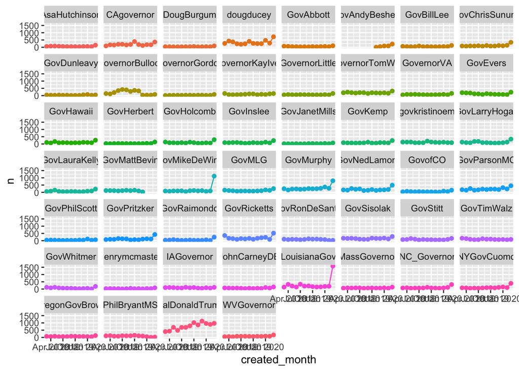

#### Let’s take a closer look at the 10 governors that tweeted the most in March, plus President Trump, on a tweets-by-month basis:

- Gavin Newsom, from his @CAgovernor twitter account, ranked 10th in number of March tweets from governors’ Twitter accounts. This March, @CAgovernor tweeted 361 tweets. The account has averaged nearly 200 tweets per month from March 2019 to March 2020, with a median tweet count of 177 tweets.

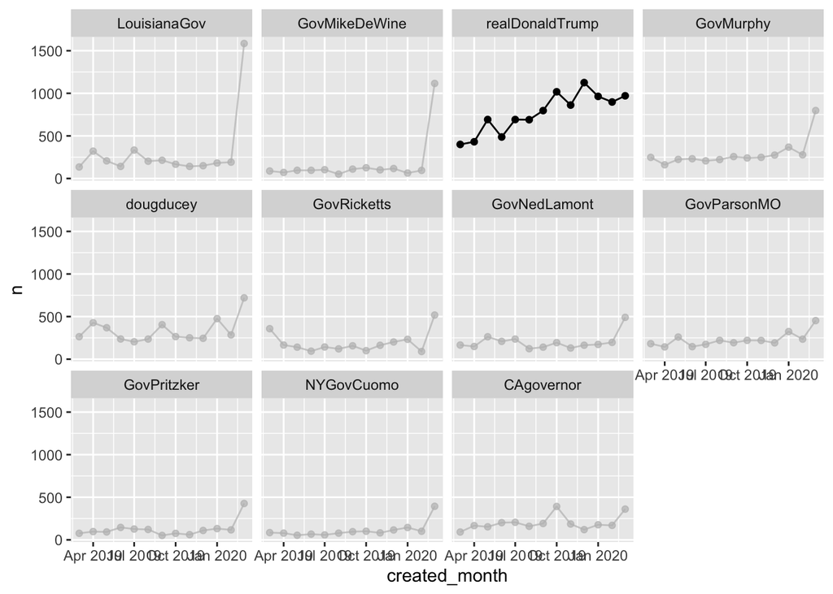

## Here’s a very wide table showing each governors’:

- monthly tweet count
- their mean and median tweet counts these last 13 months
- percent change in number of tweets comparing March 2019 to March 2020
- whether their March 2020 tweets exceeded their median tweet count
- the number of times and percentage of tweets mentioning “covid,” “coronavirus”, or “virus” directly in Feb and March 2020
- whether the percentage of March tweets mentioning “covid,” “coronavirus”, or “virus” exceeded 25%.

|  | name | screen_name | 2020-02-01_covid | 2020-03-01_covid | official | party | 2019-03-01 | 2019-04-01 | 2019-05-01 | 2019-06-01 | 2019-07-01 | 2019-08-01 | 2019-09-01 | 2019-10-01 | 2019-11-01 | 2019-12-01 | 2020-01-01 | 2020-02-01 | 2020-03-01 | mean | median | percent_change_march | more_median | percent_feb | percent_mar | over_25 |
| --- | --- | --- | --- | --- | --- | --- | --- | --- | --- | --- | --- | --- | --- | --- | --- | --- | --- | --- | --- | --- | --- | --- | --- | --- | --- | --- |
| 1 | Andrew Cuomo | NYGovCuomo | 10 | 181 | True | D | 85 | 79 | 54 | 67 | 58 | 79 | 96 | 101 | 82 | 116 | 145 | 101 | 394 | 112.076923076923 | 85 | 363.529411764706 | True | 9.9009900990099 | 45.9390862944162 | True |
| 2 | Brad Little | GovernorLittle |  | 94 | True | R | 48 | 72 | 57 | 55 | 68 | 61 | 58 | 50 | 50 | 47 | 68 | 47 | 146 | 63.6153846153846 | 57 | 204.166666666667 | True |  | 64.3835616438356 | True |
| 3 | Charlie Baker | MassGovernor | 1 | 97 | True | R | 62 | 81 | 74 | 83 | 80 | 55 | 70 | 77 | 65 | 66 | 87 | 58 | 132 | 76.1538461538462 | 74 | 112.903225806452 | True | 1.72413793103448 | 73.4848484848485 | True |
| 4 | Chris Sununu | GovChrisSununu | 4 | 150 | True | R | 84 | 70 | 89 | 83 | 102 | 74 | 118 | 79 | 83 | 118 | 100 | 135 | 342 | 113.615384615385 | 89 | 307.142857142857 | True | 2.96296296296296 | 43.859649122807 | True |
| 5 | Donald Trump | realDonaldTrump | 22 | 213 | True |  | 400 | 431 | 692 | 487 | 692 | 690 | 797 | 1018 | 862 | 1126 | 964 | 898 | 971 | 771.384615384615 | 797 | 142.75 | True | 2.44988864142539 | 21.9361483007209 | False |
| 6 | Doug Ducey | dougducey | 3 | 390 | True | R | 264 | 428 | 369 | 237 | 204 | 236 | 405 | 265 | 251 | 245 | 476 | 285 | 720 | 337.307692307692 | 265 | 172.727272727273 | True | 1.05263157894737 | 54.1666666666667 | True |
| 7 | Eric Holcomb | GovHolcomb |  | 126 | True | R | 135 | 84 | 82 | 64 | 92 | 64 | 124 | 92 | 50 | 57 | 80 | 60 | 295 | 98.3846153846154 | 82 | 118.518518518519 | True |  | 42.7118644067797 | True |
| 8 | Gina Raimondo | GovRaimondo |  | 55 | True | D | 35 | 41 | 76 | 39 | 23 | 32 | 47 | 30 | 28 | 28 | 59 | 20 | 245 | 54.0769230769231 | 35 | 600 | True |  | 22.4489795918367 | False |
| 9 | Gov. Asa Hutchinson | AsaHutchinson | 3 | 79 | True | R | 50 | 73 | 77 | 65 | 53 | 43 | 44 | 41 | 37 | 50 | 52 | 42 | 142 | 59.1538461538462 | 50 | 184 | True | 7.14285714285714 | 55.6338028169014 | True |
| 10 | Gov. Doug Burgum | DougBurgum | 1 | 58 | True | R | 35 | 33 | 28 | 28 | 29 | 33 | 36 | 50 | 26 | 33 | 39 | 31 | 92 | 37.9230769230769 | 33 | 162.857142857143 | True | 3.2258064516129 | 63.0434782608696 | True |

[output cut: 41 more lines]

#### The number of coronavirus-related tweets that mention “covid,” “coronavirus,” or “virus” specifically in the body of the tweet, begin to increase in March.

- the @CAgovernor Twitter account used the words, “covid,” “coronavirus” or “virus” verbatem in 245 tweets this past year. (This doesn’t capture other references to the pandemic)

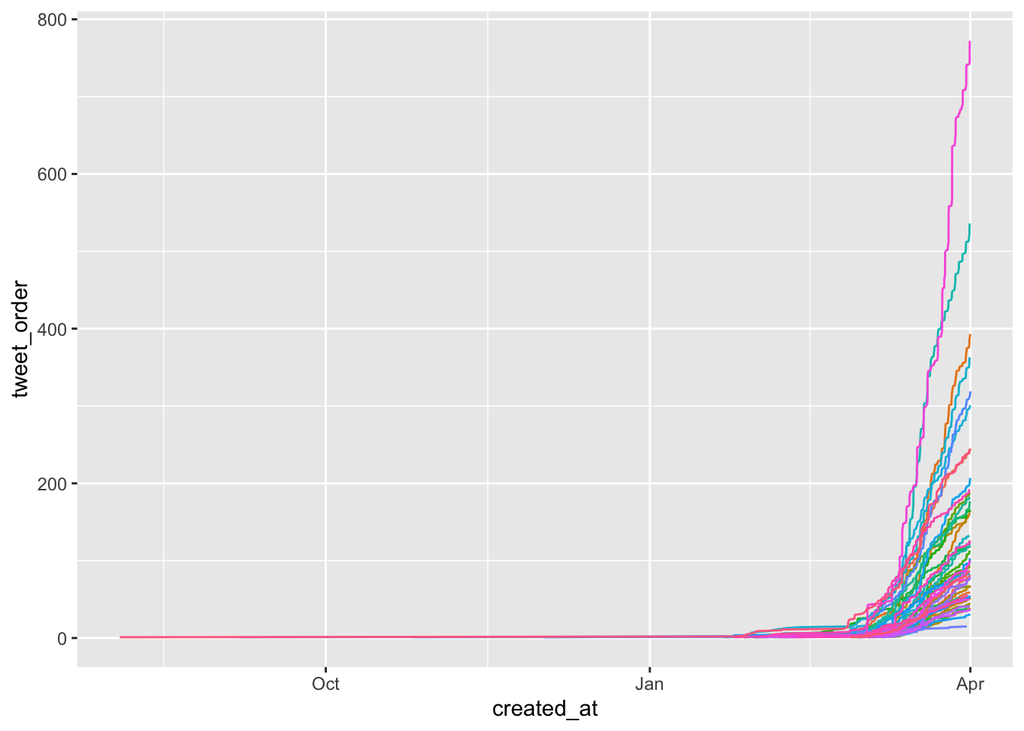

```
## # A tibble: 51 x 2
##    screen_name     total
##    <chr>           <dbl>
##  1 LouisianaGov      772
##  2 GovMikeDeWine     536
##  3 dougducey         393
##  4 GovMurphy         363
##  5 GovRicketts       319
##  6 GovNedLamont      301
##  7 CAgovernor        245
##  8 realDonaldTrump   244
##  9 GovParsonMO       207
## 10 NYGovCuomo        192
## # … with 41 more rows
```

## And COVID19 is the top hashtag used by governors this past year:

-NA means no hashtag used  
-the chart with the larger numbers looks at hashtags used by all accounts, official and personal  
-the chart with the smaller numbers looks at official accounts. When governors tweet from a single account, I consider it their official account

```
## # A tibble: 10 x 2
## # Groups:   hashtags [10]
##    hashtags             n
##    <chr>            <int>
##  1 <NA>             56454
##  2 COVID19           2057
##  3 lagov lalege      1156
##  4 gapol             1072
##  5 CaliforniaForAll   501
##  6 txlege             375
##  7 WeAreKY            371
##  8 WV WVGov           236
##  9 coronavirus        193
## 10 lalege lagov       176
```

```
## # A tibble: 10 x 2
## # Groups:   hashtags [10]
##    hashtags             n
##    <chr>            <int>
##  1 <NA>             45212
##  2 COVID19           1941
##  3 lagov lalege      1082
##  4 gapol              495
##  5 CaliforniaForAll   491
##  6 WeAreKY            323
##  7 WV WVGov           236
##  8 coronavirus        185
##  9 alpolitics         168
## 10 603Pride           156
```

#### One doesn’t need to tweet the most to get noticed.

When governors tweet with leadership during the coronavirus pandemic, followers notice and respond: Nine of the top 10 most favorited tweets from a governor’s Twitter acount these last 13 months have been coronavirus-related.

|  | name | screen_name | state | party | official | created_at | text | favorite_count | retweet_count | media_t.co | is_quote | is_retweet |
| --- | --- | --- | --- | --- | --- | --- | --- | --- | --- | --- | --- | --- |
| 1 | Jay Inslee | JayInslee | WA | D | False | 2020-02-28T04:09:09Z | I just received a call from @VP Mike Pence, thanking Washington state for our efforts to combat the coronavirus. I told him our work would be more successful if the Trump administration stuck to the s… | 309301 | 53250 |  | False | False |
| 2 | Andrew Cuomo | NYGovCuomo | NY | D | True | 2020-03-24T15:43:02Z | My mother is not expendable. Your mother is not expendable. We will not put a dollar figure on human life. We can have a public health strategy that is consistent with an economic one. No one should b… | 285842 | 73849 |  | False | False |
| 3 | Andrew Cuomo | NYGovCuomo | NY | D | True | 2020-03-24T15:52:29Z | We are not willing to sacrifice 1-2% of New Yorkers. That’s not who we are. We will fight to save every life we can. I am not giving up. | 282663 | 40470 |  | False | False |
| 4 | Governor Gretchen Whitmer | GovWhitmer | MI | D | True | 2020-03-27T02:19:58Z | Hi, my name is Gretchen Whitmer, and that governor is me 👋 I've asked repeatedly and respectfully for help. We need it. No more political attacks, just PPEs, ventilators, N95 masks, test kits. You sai… | 229421 | 59567 |  | True | False |
| 5 | Governor JB Pritzker | GovPritzker | IL | D | True | 2020-03-22T16:54:08Z | You wasted precious months when you could've taken action to protect Americans &amp;amp; Illinoisans. You should be leading a national response instead of throwing tantrums from the back seat. Where w… | 173669 | 45487 |  | True | False |
| 6 | Gavin Newsom | GavinNewsom | CA | D | False | 2019-11-03T16:41:57Z | You don’t believe in climate change. You are excused from this conversation. https://t.co/PSt8N39Er5 | 166379 | 26082 |  | True | False |
| 7 | Andrew Cuomo | NYGovCuomo | NY | D | True | 2020-03-27T16:14:17Z | I hope NY doesn’t ultimately need 30,000 ventilators. But I don't operate on opinion and hope. I operate on facts and data and science. All the projections say we will need 30,000-40,000 ventilators. … | 148744 | 23598 |  | False | False |
| 8 | Andrew Cuomo | NYGovCuomo | NY | D | True | 2020-03-25T19:28:23Z | The Four Seasons Hotel on 57th Street will provide FREE lodging to doctors, nurses &amp;amp; medical personnel currently working to respond to the #COVID19 pandemic. Thank you @FourSeasons. The first … | 144126 | 25452 |  | False | False |
| 9 | Andrew Cuomo | NYGovCuomo | NY | D | True | 2020-03-24T15:18:21Z | I do not understand the reluctance to use the federal Defense Production Act to manufacture ventilators. If not now, when? | 142989 | 29930 |  | False | False |
| 10 | Andrew Cuomo | NYGovCuomo | NY | D | True | 2020-03-21T15:18:38Z | UPDATE: We are sending 1 million N95 masks to New York City. 500,000 N95 masks will go to Long Island. We are purchasing 6,000 additional ventilators and gathering supplies from every source we can ge… | 134336 | 17918 |  | False | False |

[output cut: 90 more lines]

### Trump’s tweets still get more attention (based on the number of times a tweet is favorited) but apples to oranges. Here’s a table of top tweets, once we add Trump’s tweets to the mix:

- Jay Inslee’s top tweet (see above) ranks #52
- capped at top 100 tweets bc of size restrictions

|  | screen_name | created_at | text | favorite_count |
| --- | --- | --- | --- | --- |
| 1 | realDonaldTrump | 2019-08-02T17:41:30Z | A$AP Rocky released from prison and on his way home to the United States from Sweden. It was a Rocky Week get home ASAP A$AP! | 879647 |
| 2 | realDonaldTrump | 2020-01-03T02:32:53Z | https://t.co/VXeKiVzpTf | 814012 |
| 3 | realDonaldTrump | 2020-01-08T02:45:24Z | All is well! Missiles launched from Iran at two military bases located in Iraq. Assessment of casualties &amp;amp; damages taking place now. So far so good! We have the most powerful and well equipped… | 764333 |
| 4 | realDonaldTrump | 2019-12-25T12:26:31Z | MERRY CHRISTMAS! | 735775 |
| 5 | realDonaldTrump | 2020-01-26T23:54:34Z | Kobe Bryant despite being one of the truly great basketball players of all time was just getting started in life. He loved his family so much and had such strong passion for the future. The loss of hi… | 735478 |
| 6 | realDonaldTrump | 2019-07-19T20:01:47Z | Just spoke to @KanyeWest about his friend A$AP Rocky’s incarceration. I will be calling the very talented Prime Minister of Sweden to see what we can do about helping A$AP Rocky. So many people would … | 734567 |
| 7 | realDonaldTrump | 2019-11-27T15:54:39Z | https://t.co/11nzKwOCtU | 700861 |
| 8 | realDonaldTrump | 2020-01-05T05:11:03Z | The United States just spent Two Trillion Dollars on Military Equipment. We are the biggest and by far the BEST in the World! If Iran attacks an American Base or any American we will be sending some o… | 684981 |
| 9 | realDonaldTrump | 2020-03-14T17:31:56Z | THE UNITED STATES LOVES ITALY! https://t.co/DESUJ4QM41 | 628164 |
| 10 | realDonaldTrump | 2020-01-01T01:30:35Z | HAPPY NEW YEAR! | 576045 |

[output cut: 90 more lines]

### A look at coronavirus-related tweets by topic:

#### Gov John Bel Edwards was the first to use “social distancing” in a tweet, on 3/10

|  | name | screen_name | created_at | text | state | official | party |
| --- | --- | --- | --- | --- | --- | --- | --- |
| 1 | John Bel Edwards | LouisianaGov | 2020-03-10T19:52:32Z | It is important that the public take measures to protect their health and reduce the spread of illness, including avoiding going out in public when you are sick, washing your hands, social distancing … | LA | True | D |
| 2 | Governor Jay Inslee | GovInslee | 2020-03-11T17:26:30Z | I’m also strongly recommending the following steps: ➡️ High-risk populations should avoid social contact ➡️ Employers should maximize teleworking options ➡️ Workplaces should implement social distanci… | WA | True | D |
| 3 | Office of the Governor of California | CAgovernor | 2020-03-12T00:03:39Z | The bear is in hibernation (or, as we call it, social distancing) to protect himself from #COVID19! You can take measure to protect yourself, too: 🧼 Wash your hands for at least 20 seconds 🤒 Stay home… | CA | True | D |
| 4 | Governor Ned Lamont | GovNedLamont | 2020-03-12T01:20:01Z | This is why @GovNedLamont has been aggressive on social distancing measures to slow the spread -- travel freezes, canceling large events, nursing home visitor restrictions -- to protect our most vulne… | CT | True | D |
| 5 | Governor Phil Murphy | GovMurphy | 2020-03-12T17:54:27Z | BREAKING: Today, I am recommending the cancellation of all public gatherings of 250+ people, including parades, concerts, and sporting events. Social distancing works. This is our best chance to mitig… | NJ | True | D |
| 6 | Governor Mike DeWine | GovMikeDeWine | 2020-03-12T18:36:02Z | The purpose of these orders is to help #Ohio keep social distancing. Our citizens must not only take steps to protect themselves but to also protect others. #COVID19 #COVID19OhioReady | OH | True | R |
| 7 | Governor Ned Lamont | GovNedLamont | 2020-03-12T19:29:20Z | 1. To promote social distancing in order to minimize COVID-19 exposure, the governor is ordering a prohibition on all gatherings across the state with more than 250 people. This order applies to gathe… | CT | True | D |
| 8 | Eric Holcomb | GovHolcomb | 2020-03-12T20:27:02Z | Child care and adult day care facilities should institute social distancing and minimize large gatherings. Nursing facilities and hospitals should restrict and screen visitors. Any individual who is a… | IN | True | R |
| 9 | Governor JB Pritzker | GovPritzker | 2020-03-12T23:10:43Z | I'm asking every business able to have employees work remotely – and fortunately many can – to consider making the decision to do so immediately. Those businesses that cannot easily have employees wor… | IL | True | D |
| 10 | Office of the Governor of California | CAgovernor | 2020-03-13T02:01:56Z | California’s updated policy on mass gatherings: ☑️ Postpone/cancel non-essential gatherings of 250+ ppl ☑️ At-risk individuals should limit gatherings to &amp;lt;10 people ☑️ All should practice socia… | CA | True | D |

[output cut: 417 more lines]

#### Gov John Bel Edwards was the first to use “flatten the curve” or “flattening the curve” in a tweet, on 3/12

|  | name | screen_name | created_at | text | state | official | party |
| --- | --- | --- | --- | --- | --- | --- | --- |
| 1 | John Bel Edwards | LouisianaGov | 2020-03-12T15:51:27Z | .@LouisianaGov says the goal is to lower the peak, flatten the curve of the virus spread so that hospitals, treatment facilities are not overwhelmed. #COVID19 | LA | True | D |
| 2 | Eric Holcomb | GovHolcomb | 2020-03-13T13:14:20Z | Avoiding large gatherings can help flatten the curve of the COVID-19 outbreak. See Indiana’s guidance under the FAQs here: https://t.co/rfjA5bV5YT | IN | True | R |
| 3 | Governor John Carney | JohnCarneyDE | 2020-03-15T15:51:53Z | We can all take steps to help stop the spread of coronavirus. This article explains why social distancing is important to help flatten the curve and reduce the number of positive cases at once. https:… | DE | True | D |
| 4 | Gov. Pete Ricketts | GovRicketts | 2020-03-15T16:25:35Z | The CEO of Nebraska Medicine is warning that intensive care beds will soon be swamped in our city if we don’t work hard, now, to flatten the curve. https://t.co/WV8a1u2dRa | NE | True | R |
| 5 | Steve Bullock | GovernorBullock | 2020-03-15T23:31:55Z | Social distancing is a primary protective measure to flatten the curve of this virus. I cannot underscore the seriousness of following these measures to help our neighbors, friends, and families. | MT | True | D |
| 6 | Gov. Pete Ricketts | GovRicketts | 2020-03-16T00:02:23Z | Flattening the curve. You've probably heard about the concept. What does it mean? Why is it vital? What can you do? Read this: https://t.co/jwCCnf8aWg #Flatteningthecurve #COVIDー19 #NebraskaMed #UNMC … | NE | True | R |
| 7 | Governor Brian P. Kemp | GovKemp | 2020-03-16T02:13:22Z | Recently, the Centers For Disease Control issued new guidance discouraging public gatherings of more than fifty people. As you know, social distancing remains a top recommendation from healthcare expe… | GA | True | R |
| 8 | John Bel Edwards | LouisianaGov | 2020-03-16T18:03:59Z | More aggressive steps are necessary to fight the spread of COVID-19 across Louisiana. These limitations were difficult to make, but they are necessary to slow the spread of COVID-19, protect the healt… | LA | True | D |
| 9 | John Bel Edwards | LouisianaGov | 2020-03-16T21:04:17Z | @LouisianaGov : "We have rampted up out efforts to mitigate COVID-19...We have to flatten the curve...We cannot run the risk of overrunning critical medical services." @KSLA | LA | True | D |
| 10 | John Bel Edwards | LouisianaGov | 2020-03-16T21:04:56Z | .@LouisianaGov "We have to flatten the curve so the peak of transmission isn't as high." | LA | True | D |

[output cut: 96 more lines]

#### Most governors seem uncomfortable with the term, “shelter in place.” Gavin Newson is an exception.

|  | name | screen_name | created_at | text | state | official | party |
| --- | --- | --- | --- | --- | --- | --- | --- |
| 1 | John Bel Edwards | LouisianaGov | 2020-03-18T18:09:54Z | .@LouisianaGov just said "It may be necessary" to issue shelter in place orders for "certain localities." New Orleans is obviously the hotspot for this. He said he hopes it's not necessary but it is p… | LA | True | D |
| 2 | John Bel Edwards | LouisianaGov | 2020-03-18T18:09:57Z | .@LouisianaGov: people need to prepare themselves for enhanced mitigation efforts...it may be necessary to shelter in place in certain localities #coronavirus | LA | True | D |
| 3 | Governor Jay Inslee | GovInslee | 2020-03-19T15:46:43Z | Seniors should shelter in place during the COVID-19 outbreak. For those who can’t, grocery stores are holding senior-only hours to allow greater social distancing. Thanks to those stores and their @UF… | WA | True | D |
| 4 | Gina Raimondo | GovRaimondo | 2020-03-19T19:11:19Z | Some folks have asked if RI will order everyone to shelter in place. The answer is no. At this time, I don’t think that’s necessary. What is necessary is for everyone to keep listening to what our mes… | RI | True | D |
| 5 | Governor Mike DeWine | GovMikeDeWine | 2020-03-19T19:56:15Z | Re: shelter in place - We've already asked people to shelter in place if they can. We've asked people to stay home if they can. Some of this is just terminology. If there is no good reason to be out -… | OH | True | R |
| 6 | Brad Little | GovernorLittle | 2020-03-19T23:45:11Z | ID Dept Health &amp;amp; Welfare has issued a Shelter in Place Order for Blaine County to slow the rapid spread of the COVID-19 virus. This means everyone should stay home unless you need to perform e… | ID | True | R |
| 7 | Governor Andy Beshear | GovAndyBeshear | 2020-03-20T17:22:57Z | We have not implemented Shelter in Place, but it is not as scary as it sounds. You can still take walks &amp;amp; shop for groceries. It only builds on social distancing, which we are practicing. Any … | KY | True | D |
| 8 | Gina Raimondo | GovRaimondo | 2020-03-20T18:11:35Z | I want to reiterate that RI is not doing a shelter in place at this time. Completely shutting down has health and economic consequences, and this is not where we want to go. I want to remind everyone … | RI | True | D |
| 9 | Governor JB Pritzker | GovPritzker | 2020-03-21T01:20:23Z | Let’s all listen to Dr. Landon: “A successful shelter in place means you’re going to feel like it was all for nothing — and you’d be right. Because nothing means that nothing happened to your family, … | IL | True | D |
| 10 | Governor JB Pritzker | GovPritzker | 2020-03-21T13:42:27Z | Hay una gran cantidad de malentendidos sobre lo que significa una una orden de quedarse en casa o 'shelter in place', por eso quiero ser claro para todos. | IL | True | D |

[output cut: 12 more lines]

#### Governors seem to prefer using the terms “safer at home” and “stay home” to “shelter in place.”

|  | name | screen_name | created_at | text | state | official | party |
| --- | --- | --- | --- | --- | --- | --- | --- |
| 1 | Governor Tony Evers | GovEvers | 2020-02-07T18:59:44Z | While we have one confirmed case of Coronavirus here in Wisconsin, @DHSWI Secretary designee Andrea Palm and I want to assure you that the risk to the general public is very low. Wash your hands, cove… | WI | True | D |
| 2 | Governor Laura Kelly | GovLauraKelly | 2020-02-18T14:50:38Z | Mid-February, and Influenza is still peaking. Not a good sign. Do not let the (occasional) good weather fool you. We are in what appears to be the worst part of the flu season. Wash hands, cover cough… | KS | True | D |
| 3 | Jay Inslee | JayInslee | 2020-02-24T22:53:46Z | There's no question: A parent should be able to stay home with a newborn. A son or daughter should be able to care for a sick parent. We all should be able to take time to heal from injury or sickness… | WA | False | D |
| 4 | Governor David Ige | GovHawaii | 2020-02-26T23:25:04Z | RT @HIgov_Health: You have the power to stop the spread of infectious disease. This is why it's important to stay home when sick. https://t.co/kv5wAoC1Kx https://t.co/duNXNd8d3f | HI | True | D |
| 5 | Michelle Lujan Grisham | GovMLG | 2020-02-27T14:46:28Z | STOP THE SPREAD OF GERMS! You can help prevent the spread of respiratory diseases like COVID-19. Wash your hands (20 seconds), stay home when you're sick, and cover your cough or sneeze with a tissue.… | NM | True | D |
| 6 | Governor JB Pritzker | GovPritzker | 2020-02-28T17:01:05Z | Take extra care to wash your hands, stay home if you’re sick, cover your mouth and nose during any coughs or sneezes, and clean often-touched objects and surfaces. Please visit a doctor if you're expe… | IL | True | D |
| 7 | Governor David Ige | GovHawaii | 2020-02-28T23:58:38Z | To protect yourself from #COVID19, avoid being exposed to the virus and use everyday prevention action to prevent the spread of respiratory virus: 1) cover your cough 2) wash your hands 3) stay home w… | HI | True | D |
| 8 | Governor Phil Murphy | GovMurphy | 2020-02-29T16:29:23Z | Small steps to help prevent the spread of coronavirus: 😷Avoid close contact w sick people 😨If you feel sick, opt to stay home if possible 🤧Cover coughs and sneezes 🙏Wash your hands 👀Avoid touching you… | NJ | True | D |
| 9 | Andrew Cuomo | NYGovCuomo | 2020-03-01T21:40:00Z | Many people with the flu can't afford to stay home from work without pay and they risk spreading the virus when they come into work sick. We need to pass #PaidSickLeave to help our workers and make ou… | NY | True | D |
| 10 | Gov. Pete Ricketts | GovRicketts | 2020-03-02T16:02:51Z | All public officials are now using an ‘elbow bump,’ instead of a handshake. The big message @GovRicketts passed along was to practice safe hygiene techniques. He adds treat it as a major flu outbreak.… | NE | True | R |

[output cut: 389 more lines]

#### As cases rise, governors have also been using Twitter to plead for medical supplies, including N95 masks, PPE, ventilators, and test kits, in short supply

|  | name | screen_name | created_at | text | state | official | party |
| --- | --- | --- | --- | --- | --- | --- | --- |
| 1 | Governor Phil Murphy | GovMurphy | 2020-02-12T19:17:54Z | 1️⃣ FACT: There are currently no confirmed cases of novel #coronavirus in NJ. 2️⃣ FACT: There are no persons under investigation at this time. 3️⃣ FACT: @CDCgov does not currently recommend the use of… | NJ | True | D |
| 2 | Governor David Ige | GovHawaii | 2020-02-29T00:01:29Z | US labs can test for infection with #COVID19 using existing CDC test kits. For specific instructions on the newest protocol using CDC tests, visit https://t.co/nmkWTkgrKC. https://t.co/GoNUB98qfB | HI | True | D |
| 3 | Office of the Governor of California | CAgovernor | 2020-02-29T17:36:22Z | New CDC test kits to detect Coronavirus Disease 2019 (COVID-19) are now available in California, and can be used to do diagnostic testing in the community. Learn more: https://t.co/zTyEU0dBJ8 #COVID19… | CA | True | D |
| 4 | Gavin Newsom | GavinNewsom | 2020-02-29T17:36:51Z | New CDC test kits to detect Coronavirus Disease 2019 (COVID-19) are now available in California, and can be used to do diagnostic testing in the community. Learn more: https://t.co/zTyEU0dBJ8 #COVID19… | CA | False | D |
| 5 | Office of the Governor of California | CAgovernor | 2020-03-02T22:00:05Z | ICYMI: Recently CDPH announced new @CDCgov test kits to detect #Coronavirus Disease 2019 (#COVID19) are now available in California. Learn more about California’s expanded testing capabilities: https:… | CA | True | D |
| 6 | Office of the Governor of California | CAgovernor | 2020-03-04T01:05:33Z | Governor @GavinNewsom, state health &amp;amp; emergency officials are releasing millions of N95 masks to address shortages caused by #COVID19. @CDCgov approved use of these &amp;amp; CA is mobilizing … | CA | True | D |
| 7 | Gov. Pete Ricketts | GovRicketts | 2020-03-04T14:47:09Z | #Nebraska Congress members are supporting legislation to protect makers of medical masks amid the spread of the #coronavirus. https://t.co/tIn4op9iPo https://t.co/YI8l6o716A | NE | True | R |
| 8 | Office of the Governor of California | CAgovernor | 2020-03-05T19:26:52Z | Multiple public health laboratories throughout the state have received #COVID19 test kits, expanding California’s testing capabilities. @CAgovernor requested the additional test kits from the @CDCgov.… | CA | True | D |
| 9 | Gavin Newsom | GavinNewsom | 2020-03-05T19:27:03Z | Multiple public health laboratories throughout the state have received #COVID19 test kits, expanding California’s testing capabilities. @CAgovernor requested the additional test kits from the @CDCgov.… | CA | False | D |
| 10 | Office of the Governor of California | CAgovernor | 2020-03-06T03:34:35Z | Governor @GavinNewsom's emergency proclamation will make additional resources available in response to the global #COVID19 outbreak. Test kits are in-use to help medical experts identify coronavirus, … | CA | True | D |

[output cut: 311 more lines]

#### Who uses racist language on Twitter to talk about SARS-CoV-2? None of the governors. Trump, nine times.

|  | name | screen_name | created_at | text | state | official | party |
| --- | --- | --- | --- | --- | --- | --- | --- |
| 1 | Donald Trump | realDonaldTrump | 2020-03-14T03:58:31Z | RT @AndrewHClark: Oh no! CNN's reporter just called it the "Wuhan virus" and added "which originated as we know in Wuhan China." Someo… |  | True |  |
| 2 | Donald Trump | realDonaldTrump | 2020-03-16T22:51:54Z | The United States will be powerfully supporting those industries like Airlines and others that are particularly affected by the Chinese Virus. We will be stronger than ever before! |  | True |  |
| 3 | Donald Trump | realDonaldTrump | 2020-03-17T12:22:11Z | Cuomo wants “all states to be treated the same.” But all states aren’t the same. Some are being hit hard by the Chinese Virus some are being hit practically not at all. New York is a very big “hotspot… |  | True |  |
| 4 | Donald Trump | realDonaldTrump | 2020-03-18T10:41:14Z | For the people that are now out of work because of the important and necessary containment policies for instance the shutting down of hotels bars and restaurants money will soon be coming to you. The … |  | True |  |
| 5 | Donald Trump | realDonaldTrump | 2020-03-18T11:12:49Z | I will be having a news conference today to discuss very important news from the FDA concerning the Chinese Virus! |  | True |  |
| 6 | Donald Trump | realDonaldTrump | 2020-03-18T11:46:33Z | I always treated the Chinese Virus very seriously and have done a very good job from the beginning including my very early decision to close the “borders” from China - against the wishes of almost all… |  | True |  |
| 7 | Donald Trump | realDonaldTrump | 2020-03-18T21:37:22Z | I only signed the Defense Production Act to combat the Chinese Virus should we need to invoke it in a worst case scenario in the future. Hopefully there will be no need but we are all in this TOGETHER… |  | True |  |
| 8 | Donald Trump | realDonaldTrump | 2020-03-22T02:53:27Z | CHINESE VIRUS FACT CHECK https://t.co/qJugCylvE2 |  | True |  |
| 9 | Donald Trump | realDonaldTrump | 2020-03-23T01:20:08Z | My friend (always there when I’ve needed him!) Senator @RandPaul was just tested “positive” from the Chinese Virus. That is not good! He is strong and will get better. Just spoke to him and he was in … |  | True |  |